# Stack (Tumpukan)

**Stack** adalah struktur data yang dapat menampung banyak elemen, dan elemen terakhir yang ditambahkan adalah elemen pertama yang dihapus. Tumpukan (stack): kumpulan barang yang terurut di mana penambahan barang baru dan penghapusan barang yang sudah ada selalu terjadi di ujung yang sama.

Ujung ini biasanya disebut sebagai **“top.”** atau atas ssedangkan Ujung yang berlawanan dengan atas dikenal sebagai **“base.”** atau dasar.

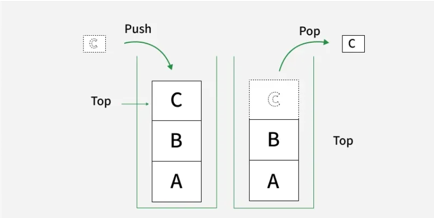

Seperti tumpukan pancake, pancake ditambahkan dan dikeluarkan dari atas. Jadi, ketika mengeluarkan pancake, itu selalu pancake terakhir yang Anda tambahkan. Cara mengatur elemen seperti ini disebut LIFO: Last In First Out (Terakhir Masuk, Pertama Keluar).

Stack adalah struktur data linier yang mengikuti prinsip **Last-In-First-Out (LIFO)**. Bayangkan seperti tumpukan pancake - Anda hanya bisa menambah atau mengurangi pancake dari bagian atas. Prinsip pemesanan ini terkadang disebut **LIFO/FILO.**

Operasi dasar yang dapat kita lakukan pada sebuah stack adalah:

- Push: Menambahkan elemen baru ke dalam tumpukan.
- Pop: Menghapus dan mengembalikan elemen teratas dari tumpukan.
- Peek: Mengembalikan elemen teratas (terakhir) pada tumpukan.
- isEmpty: Memeriksa apakah tumpukan kosong.
- Ukuran: Menemukan jumlah elemen dalam tumpukan.

Stack dapat diimplementasikan dengan menggunakan array atau linked list.

Stack dapat digunakan untuk mengimplementasikan mekanisme undo, untuk kembali ke keadaan sebelumnya, untuk membuat algoritma pencarian mendalam (depth-first search) dalam graf, atau untuk penelusuran balik (backtracking).

### Implementasi Stack menggunakan List Python

Untuk list (dan array) Python, sebuah tumpukan dapat terlihat dan berperilaku seperti ini:

x = [5, 6, 2, 9, 3, 8, 4, 2]

dari list ini kita dapat menemabahkan elemen baru ke dalam list menggunakan Push dan menggunakan Pop untuk menghapus dan mengembalikan elemen teratas dari List

Karena list Python memiliki dukungan yang baik untuk fungsionalitas yang dibutuhkan untuk mengimplementasikan stack, kita mulai dengan membuat stack dan melakukan operasi stack hanya dengan beberapa baris seperti ini:

```python
stack = []

stack.append("Buku")
stack.append("Pensil")
stack.append("Penghapus")

print("Stack setelah push:", stack)

item_keluar = stack.pop()
print("Item yang keluar:", item_keluar)
print("Stack setelah pop:", stack)
print("Item teratas:", stack[-1])

if len(stack) == 0:
    print("Stack kosong")
else:
    print("Stack tidak kosong")
```

```
Stack setelah push: ['Buku', 'Pensil', 'Penghapus']
Item yang keluar: Penghapus
Stack setelah pop: ['Buku', 'Pensil']
Item teratas: Pensil
Stack tidak kosong
```

Meskipun list Python dapat digunakan sebagai stack, membuat kelas Stack khusus memberikan enkapsulasi yang lebih baik dan fungsionalitas tambahan:

```python
class Tumpukan:
    def __init__(self):
        self.data = []

    def tambah(self, nilai):
        self.data.append(nilai)

    def ambil(self):
        if len(self.data) == 0:
            return "Tumpukan kosong"
        return self.data.pop()

    def lihat(self):
        if len(self.data) == 0:
            return "Tumpukan kosong"
        return self.data[-1]

    def kosong(self):
        return len(self.data) == 0

    def jumlah(self):
        return len(self.data)

tumpukan_saya = Tumpukan()

tumpukan_saya.tambah("F")
tumpukan_saya.tambah("a")
tumpukan_saya.tambah("i")
tumpukan_saya.tambah("q")

print("Isi tumpukan:", tumpukan_saya.data)
print("Data diambil:", tumpukan_saya.ambil())
print("Isi setelah diambil:", tumpukan_saya.data)
print("Data teratas:", tumpukan_saya.lihat())
print("Apakah kosong:", tumpukan_saya.kosong())
print("Jumlah data:", tumpukan_saya.jumlah())
```

```
Isi tumpukan: ['F', 'a', 'i', 'q']
Data diambil: q
Isi setelah diambil: ['F', 'a', 'i']
Data teratas: i
Apakah kosong: False
Jumlah data: 3
```

### Implementasi Stack menggunakan Linked List

Sebuah linked list terdiri dari node yang berisi data tertentu, dan sebuah pointer ke node berikutnya.

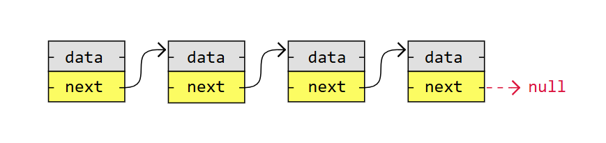

Alasan untuk mengimplementasikan stack menggunakan list/array:

**Efisien Memori**: Elemen array tidak menyimpan alamat elemen berikutnya seperti halnya node pada linked list. **Lebih mudah diimplementasikan dan dipahami**: Menggunakan array untuk mengimplementasikan stack membutuhkan lebih sedikit kode daripada menggunakan linked list, dan karena alasan ini biasanya juga lebih mudah dipahami. Alasan mengapa array **tidak** digunakan untuk mengimplementasikan stack:

**Ukuran tetap:** Sebuah array menempati bagian memori yang tetap. Ini berarti bahwa array tersebut dapat menggunakan lebih banyak memori daripada yang dibutuhkan, atau jika array penuh, array tersebut tidak dapat menampung elemen lagi.

Salah satu keuntungan besar menggunakan linked list adalah node disimpan di mana pun ada ruang kosong di memori, node tidak perlu disimpan berdekatan satu sama lain seperti elemen yang disimpan dalam array. Keuntungan lain dari linked list adalah ketika menambahkan atau menghapus node, node lain dalam list tidak perlu digeser.

Beginilah cara mengimplementasikan stack menggunakan linked list.

```python
class Node:
    def __init__(self, data):
        self.data = data
        self.berikutnya = None

class Stack:
    def __init__(self):
        self.atas = None

    def push(self, data):
        node_baru = Node(data)
        node_baru.berikutnya = self.atas
        self.atas = node_baru

    def pop(self):
        if self.atas is None:
            return "Stack kosong"
        data = self.atas.data
        self.atas = self.atas.berikutnya
        return data

    def peek(self):
        if self.atas is None:
            return "Stack kosong"
        return self.atas.data

    def kosong(self):
        return self.atas is None

    def tampil(self):
        sekarang = self.atas
        while sekarang:
            print(sekarang.data, end=" -> ")
            sekarang = sekarang.berikutnya
        print("None")

stack_saya = Stack()

stack_saya.push("A")
stack_saya.push("B")
stack_saya.push("C")

print("Isi stack:")
stack_saya.tampil()

print("Pop:", stack_saya.pop())
print("Peek:", stack_saya.peek())
print("Apakah kosong:", stack_saya.kosong())

print("Isi stack setelah pop:")
stack_saya.tampil()
```

```
Isi stack:
C -> B -> A -> None
Pop: C
Peek: B
Apakah kosong: False
Isi stack setelah pop:
B -> A -> None
```

### Soal-soal

1. Apa yang dimaksud dengan struktur data Stack?

A. Struktur data dengan prinsip FIFO

B. Struktur data dengan prinsip LIFO

C. Struktur data berbentuk pohon

D. Struktur data berbentuk graf

jawaban:B. Struktur data dengan prinsip LIFO

2. Operasi utama pada Stack adalah…

A. Insert dan Delete

B. Push dan Pop

C. Enqueue dan Dequeue

D. Search dan Sort

jawwabn:B. Push dan Pop

3. Jika stack berisi:

[10, 20, 30] Elemen terakhir yang dimasukkan adalah?

jawaban:30

4. Jika dilakukan operasi pop() pada stack:

[5, 8, 12, 20] Maka elemen yang keluar adalah?

Jawaban: 20

5. Diketahui stack kosong. Lakukan:

Push(A)

Push(B)

Push(C)

Pop(C)

Pop(B)

Push(D)

Tentukan isi stack akhir!

Jawaban: [A, D]

6. Diketahui stack kosong. Lakukan operasi berikut:

Push(10)

Push(15)

Push(20)

Pop()

Push(25)

Tentukan isi stack akhir!

Jawaban: [10, 15, 25]

7. Buatlah fungsi untuk mengecek apakah suatu string merupakan palindrome menggunakan stack.

Input: "KATAK"

Output: Palindrome

```python
#jawaban
kata = input("Masukkan kata: ")
stack = []

for huruf in kata:
    stack.append(huruf)

hasil = ""
for huruf in kata:
    hasil += stack.pop()

if hasil == kata:
    print("Palindrome")
else:
    print("Bukan Palindrome")
```

```
Palindrome
```

```python
class Stack:
    def __init__(self):
        self.stack = []

    def push(self, element):
        self.stack.append(element)

    def pop(self):
        if self.isEmpty():
            return "tidak ada"
        return self.stack.pop()

    def peek(self):
        if self.isEmpty():
            return "tidak ada"
        return self.stack[-1]

    def size(self):
        return len(self.stack)

    def isEmpty(self):
        return len(self.stack) == 0
tumpukan = Stack()

tumpukan.push('F')
tumpukan.push('A')
tumpukan.push('I')
tumpukan.push('Q')

print("Stack:", tumpukan.stack)
print("Pop:", tumpukan.pop())
print(tumpukan.stack)
print("Peek:", tumpukan.peek())
print("Is Empty:", tumpukan.isEmpty())
print("Size:", tumpukan.size())
```

```
Stack: ['F', 'A', 'I', 'Q']
Pop: Q
['F', 'A', 'I']
Peek: I
Is Empty: False
Size: 3
```

1.Buat program untuk membalik urutan kata dalam sebuah kalimat menggunakan stack.

Input: Saya belajar struktur data

Output: data struktur belajar Saya

```python
kalimat = "Saya belajar struktur data"
stack = []
kata = ""
hasil = ""

for huruf in kalimat:
    if huruf == " ":
        stack.append(kata)
        kata = ""
    else:
        kata = kata + huruf

stack.append(kata)

while stack:
    hasil = hasil + stack.pop() + " "

print(hasil)
```

```
data struktur belajar Saya
```

2.Buat program yang:

Mengisi stack dengan beberapa angka.

Menghitung jumlah elemen dalam stack tanpa menggunakan fungsi bawaan len()

```python
stack = [10, 20, 30, 40, 50]
jumlah = 0

while stack:
    stack.pop()
    jumlah += 1

print("Jumlah elemen:", jumlah)
```

```
Jumlah elemen: 5
```

3.Diketahui stack berisi angka:

[10, 20, 30, 40, 50]

Buat program untuk menghapus angka 30 tanpa merusak urutan elemen lainnya.

```python
stack = [10, 20, 30, 40, 50]
stack_baru = []

while stack:
    elemen = stack.pop()
    if elemen != 30:
        stack_baru.append(elemen)

while stack_baru:
    stack.append(stack_baru.pop())

print(stack)
```

```
[10, 20, 40, 50]
```

Berikut adalah fungsi untuk pengecekan kurung pada suatu string matematika

```python
def parenthesesCheck(strMath):
    kurung = {')': '(', '}': '{', ']': '['}
    kurungBuka = kurung.values()
    kurungTutup = kurung.keys()
    temp = []

    for ch in strMath:
        if ch in kurungBuka:
            temp.append(ch)
        elif ch in kurungTutup:
            if len(temp) == 0:
                return 'Kelebihan Kurung Tutup'
            tempKurung = temp.pop()
            if tempKurung != kurung[ch]:
                return 'Tidak Cocok kurungnya'

    if len(temp) > 0:
        return 'Kelebihan Kurung Buka'

    return 'OK'

print(parenthesesCheck("(2 + 3) * {4 / [1 - 2]}"))
print(parenthesesCheck("(2 + 3"))
print(parenthesesCheck("2 + 3)"))
print(parenthesesCheck("(2 + 3]"))
```

```
OK
Kelebihan Kurung Buka
Kelebihan Kurung Tutup
Tidak Cocok kurungnya
```

## Soal-soal

1. Buat program stack dengan operasi push, pop, peek, isEmpty, size.

```python
class Stack:
    def __init__(self):
        self.data = []

    def push(self, item):
        self.data.append(item)

    def pop(self):
        if not self.isEmpty():
            return self.data.pop()
        return "Stack kosong"

    def peek(self):
        if not self.isEmpty():
            return self.data[-1]
        return "Stack kosong"

    def isEmpty(self):
        return len(self.data) == 0

    def size(self):
        return len(self.data)

s = Stack()
s.push(10)
s.push(20)
print(s.peek())
```

```
20
```

2. Tentukan isi stack setelah operasi: push(10), push(20), push(30), pop(), push(40).
1. push(10) → [10]
2. push(20) → [10, 20]
3. push(30) → [10, 20, 30]
4. pop() → [10, 20]
5. push(40) → [10, 20, 40]

Jawaban: [10, 20, 40]

3. Buat program membalik kata menggunakan stack.

```python
def balik_kata(kata):
    stack = []

    for huruf in kata:
        stack.append(huruf)

    hasil = ""
    while stack:
        hasil += stack.pop()

    return hasil

print(balik_kata("FAIQ"))  # QIAF
```

4. Cek keseimbangan tanda kurung menggunakan stack.

```python
def cek_kurung(expr):
    stack = []
    pasangan = {')': '(', '}': '{', ']': '['}

    for char in expr:
        if char in "({[":
            stack.append(char)
        elif char in ")}]":
            if not stack or stack.pop() != pasangan[char]:
                return "Tidak seimbang"

    return "Seimbang" if not stack else "Tidak seimbang"

print(cek_kurung("(3 + [2-1])"))
```

```
Seimbang
```

5. Hitung jumlah elemen genap dalam stack.

```python
def hitung_genap(stack):
    genap = 0

    for item in stack:
        if item % 2 == 0:
            genap += 1
    return genap

A = [1, 3, 5, 8, 10, 4]
print(hitung_genap(A))
```

```
3
```